# Customer Segmentation

### Mário Damhur

# Schedule

1. Context
2. Challenge
3. Solution Development
4. Conclusion & Demonstration

# 1. Context

- In the retail context, knowing the public's profile is very important for building a healthy and long-term relationship with customers.
- A well-defined segmentation can help in the allocation of *marketing* resources.

# 2. Challenge

# Problem

- Defining more effective sales and *marketing* strategies to better serve consumers.

# Cause

- Possible decrease in the number of customers.
- Increase in the rate of complaints.

# Solution

- Use of machine learning techniques to segment customers.
- Visualization of segments can be done by smartphone

# 3. Solution Development

# Data Description

```python
print('Number of Rows: {}'.format(df1.shape[0]))
print('Number of Columns: {}'.format(df1.shape[1]))
```

```
Number of Rows: 541909
Number of Columns: 8
```

# Descriptive Statistics

```python
df_describe = df1[num_vars].describe()
df_range = pd.DataFrame(df1[num_vars].apply(lambda x: x.max() - x.min())).T
df_skew = pd.DataFrame(df1[num_vars].apply(lambda x: x.skew())).T
df_kurtosis = pd.DataFrame(df1[num_vars].apply(lambda x: x.kurtosis())).T

df_num_statistics = pd.concat([df_describe, df_range, df_skew, df_kurtosis]).T.reset_index()
df_num_statistics.columns = ['attributes', 'count', 'mean', 'std', 'min', '25%', '50%', '75%', 'max', 'range', 'skew', 'kurtosis']
df_num_statistics
```

|  | attributes | count | mean | std | min | 25% | 50% | 75% | max | range | skew | kurtosis |
| --- | --- | --- | --- | --- | --- | --- | --- | --- | --- | --- | --- | --- |
| 0 | quantity | 401604.0 | 12.183273 | 250.283037 | -80995.0 | 2.00 | 5.00 | 12.00 | 80995.0 | 161990.0 | 0.179957 | 93140.274032 |
| 1 | unit_price | 401604.0 | 3.474064 | 69.764035 | 0.0 | 1.25 | 1.95 | 3.75 | 38970.0 | 38970.0 | 449.316245 | 243760.949868 |
| 2 | customer_id | 401604.0 | 15281.160818 | 1714.006089 | 12346.0 | 13939.00 | 15145.00 | 16784.00 | 18287.0 | 5941.0 | 0.034215 | -1.179861 |

# General Questions and Some Hyphotesis of the EDA

**Questions**

1. What are the top selling products?
2. What are the best months to sell?
3. Which countries have the most transactions?

**Hyphotesis**

1. On holiday sells more.
2. Sells more in the second semester of the year.
3. Sells less on weekends.
4. Sells more after the 10th of each month.

# Questions

# Q1. What are the top selling products?

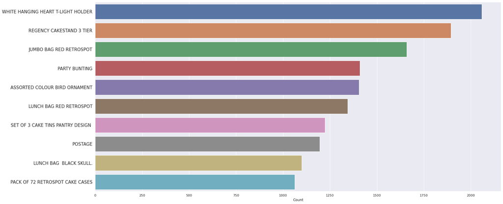

```python
top_products = df3['description'].value_counts()[:10]
sns.barplot(y=top_products.index, x=top_products.values)
plt.xlabel('Count')
plt.yticks(fontsize=15);
```

# Q2. What are the best months to sell?

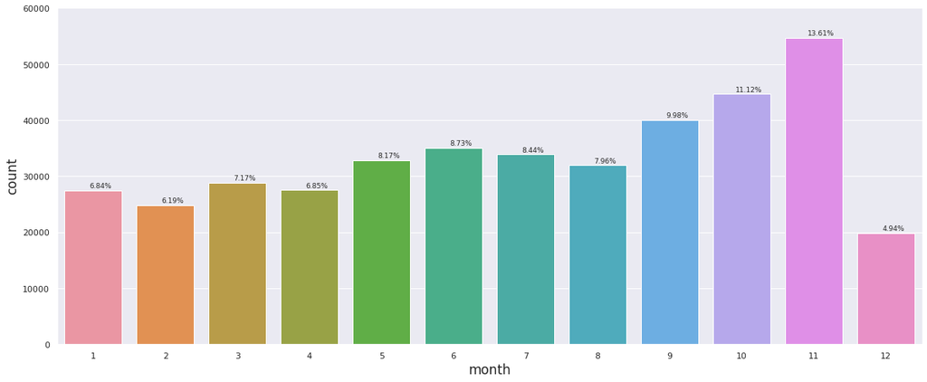

```python
plot_perc('month', df3, order=False, rotation=False);
```

# Q3. Which countries have the most transactions?

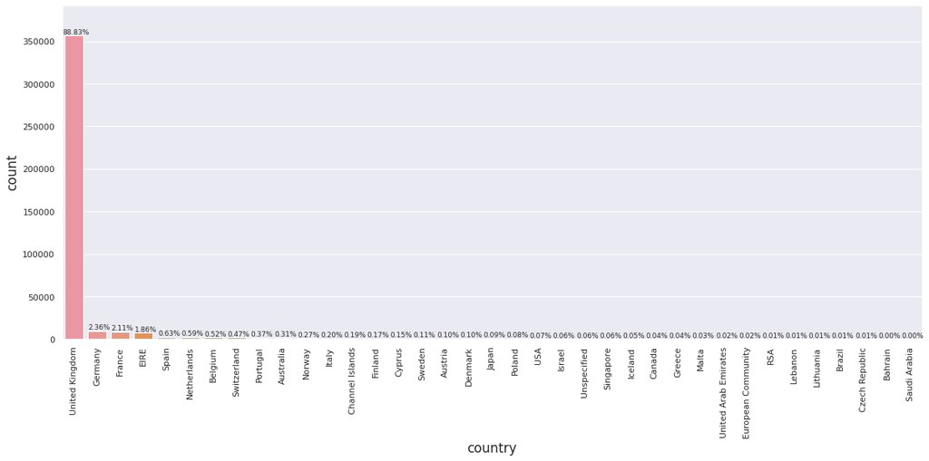

```python
plot_perc('country', df3, order=True, rotation=True);
```

# Hyphotesis

# H4. On holiday sells more.

**FALSE** It did not occur in any of the months.

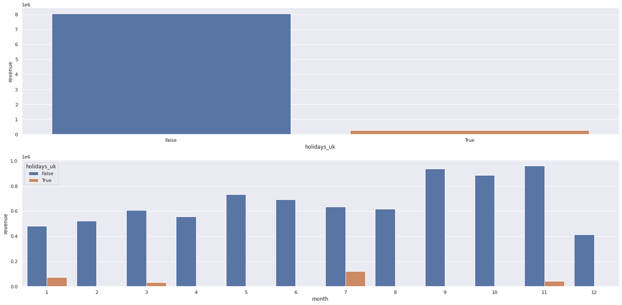

```python
aux1 = df3[['holidays_uk', 'revenue']].groupby('holidays_uk').sum().reset_index()

plt.subplot(2,1,1)
sns.barplot(x='holidays_uk', y='revenue', data=aux1);

aux2 = df3[['month', 'holidays_uk', 'revenue']].groupby(['month', 'holidays_uk']).sum().reset_index()
plt.subplot(2,1,2)
sns.barplot(x='month', y='revenue', hue='holidays_uk', data=aux2);
```

# H5. Sells more in the second semester of the year.

**TRUE** Seels more in the second semester of the year.

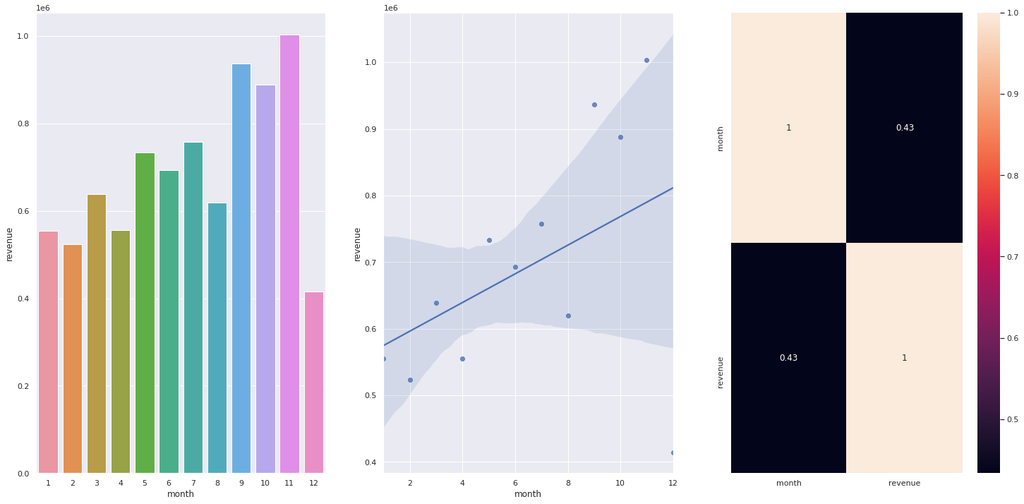

```python
aux1 = df3[['month', 'revenue']].groupby('month').sum().reset_index()

plt.subplot(1, 3, 1)
sns.barplot(x='month', y='revenue', data=aux1);

plt.subplot(1, 3, 2)
sns.regplot(x='month', y='revenue', data=aux1);

plt.subplot(1, 3, 3)
sns.heatmap(aux1.corr(method='pearson'), annot=True);
```

# H6. Sells less on weekends.

**TRUE** Sells less on weekends.

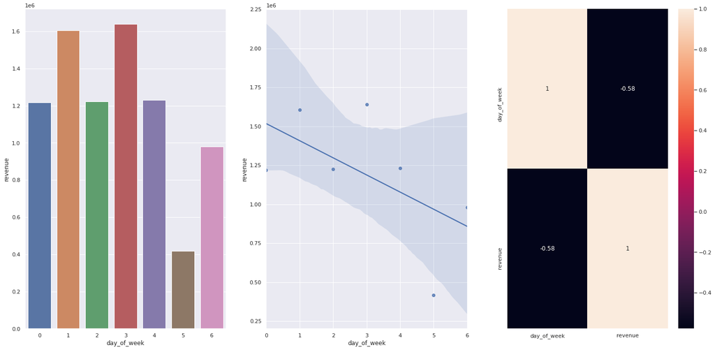

```python
aux1 = df3[['day_of_week', 'revenue']].groupby('day_of_week').sum().reset_index()

plt.subplot(1, 3, 1)
sns.barplot(x='day_of_week', y='revenue', data=aux1);

plt.subplot(1, 3, 2)
sns.regplot(x='day_of_week', y='revenue', data=aux1);

plt.subplot(1, 3, 3)
sns.heatmap(aux1.corr(method='pearson'), annot=True);
```

# H7. Sells more after the 10th of each month.

**True** Sells more after the 10th of each month.

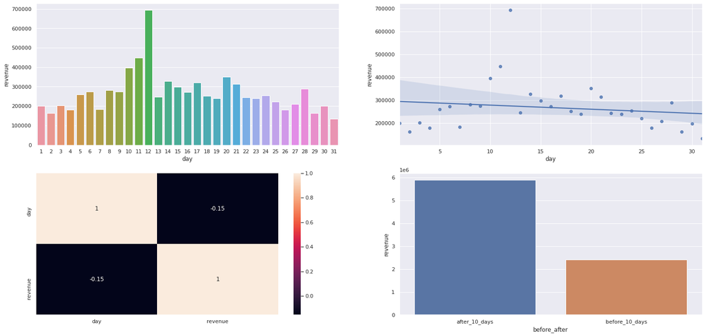

```python
aux1 = df3[['day', 'revenue']].groupby('day').sum().reset_index()

plt.subplot(2, 2, 1)
sns.barplot(x='day', y='revenue', data=aux1);

plt.subplot(2, 2, 2)
sns.regplot(x='day', y='revenue', data=aux1);

plt.subplot(2, 2, 3)
sns.heatmap(aux1.corr(method='pearson'), annot=True);

aux1['before_after'] = aux1['day'].apply( lambda x: 'before_10_days' if x <= 10 else 'after_10_days' )
aux2 = aux1[['before_after', 'revenue']].groupby( 'before_after' ).sum().reset_index()

plt.subplot( 2, 2, 4 )
sns.barplot( x='before_after', y='revenue', data=aux2 );
```

# RFM Analysis

This is a method used to analyze customer behavior and define market segments.

- **R (Recency)**: How recently a customer made a purchase. It is an important predictor, as a customer who recently bought is more likely to buy again than one who bought a long time ago, in addition to being more likely to respond to promotions.
- **F (Frequency)**: How often a customer makes a purchase. If a customer buys frequently, he is expected to buy again.
- **M (Monetary)**: How much money a customer spends on purchases. Those customers who spent a lot have more value for the organization compared to those who spent less

# Recency

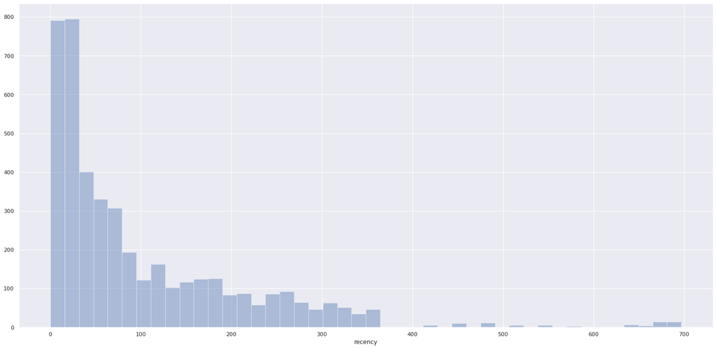

```python
sns.distplot(recency['recency'], kde=False);
```

# Frequency

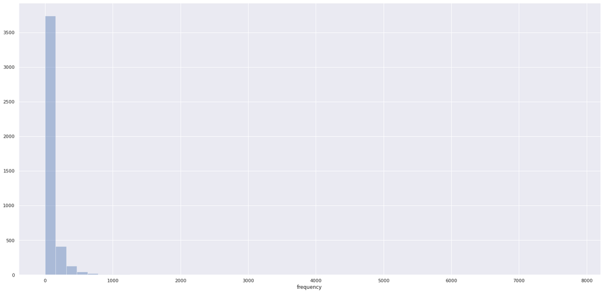

```python
sns.distplot(frequency['frequency'], kde=False);
```

# Monetary

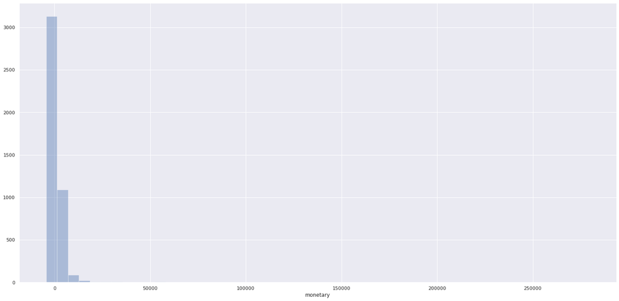

```python
sns.distplot(monetary['monetary'], kde=False);
```

# Machine Learning Model

# Recency Score

```python
kmeans = KMeans(n_clusters=5)

df5['recency_cluster'] = kmeans.fit_predict(recency_data)

df5 = order_cluster('recency_cluster', 'recency', df5, False)
df5.groupby('recency_cluster')['recency'].describe()
```

| recency_cluster | count | mean | std | min | 25% | 50% | 75% | max |
| --- | --- | --- | --- | --- | --- | --- | --- | --- |
| 0 | 76.0 | 588.934211 | 94.109912 | 454.0 | 485.0 | 638.0 | 666.00 | 697.0 |
| 1 | 502.0 | 291.448207 | 39.048467 | 236.0 | 261.0 | 285.0 | 319.75 | 424.0 |
| 2 | 647.0 | 179.131376 | 27.664449 | 134.0 | 156.0 | 178.0 | 201.00 | 235.0 |
| 3 | 983.0 | 87.095626 | 22.136059 | 55.0 | 69.0 | 82.0 | 107.00 | 132.0 |
| 4 | 2163.0 | 22.448451 | 15.255866 | 0.0 | 11.0 | 20.0 | 33.00 | 54.0 |

# Frequency Score

```python
frequency_data = df5[['frequency']]

kmeans = KMeans(n_clusters=5)

df5['frequency_cluster'] = kmeans.fit_predict(frequency_data)

df5 = order_cluster('frequency_cluster', 'frequency', df5, True)
df5.groupby('frequency_cluster')['frequency'].describe()
```

| frequency_cluster | count | mean | std | min | 25% | 50% | 75% | max |
| --- | --- | --- | --- | --- | --- | --- | --- | --- |
| 0 | 3346.0 | 35.439331 | 27.494922 | 1.0 | 13.00 | 28.0 | 53.00 | 106.0 |
| 1 | 825.0 | 178.500606 | 59.800947 | 107.0 | 128.00 | 161.0 | 217.00 | 329.0 |
| 2 | 178.0 | 482.325843 | 137.337579 | 331.0 | 379.25 | 444.0 | 547.00 | 954.0 |
| 3 | 18.0 | 1478.055556 | 516.150283 | 1010.0 | 1118.25 | 1225.5 | 1660.25 | 2759.0 |
| 4 | 4.0 | 5824.250000 | 1449.742592 | 4459.0 | 4960.75 | 5513.0 | 6376.50 | 7812.0 |

# Monetary Score

```python
monetary_data = df5[['monetary']]

kmeans = KMeans(n_clusters=5)

df5['monetary_cluster'] = kmeans.fit_predict(monetary_data)

df5 = order_cluster('monetary_cluster', 'monetary', df5, True)
df5.groupby('monetary_cluster')['monetary'].describe()
```

| monetary_cluster | count | mean | std | min | 25% | 50% | 75% | max |
| --- | --- | --- | --- | --- | --- | --- | --- | --- |
| 0 | 4066.0 | 940.065080 | 958.287198 | -4287.63 | 270.6500 | 589.850 | 1298.5050 | 4464.10 |
| 1 | 270.0 | 8032.726741 | 3757.306791 | 4478.53 | 5323.9425 | 6678.785 | 9516.3250 | 21535.90 |
| 2 | 28.0 | 40913.384286 | 13160.882637 | 25748.35 | 28595.5500 | 35079.280 | 52855.3025 | 65892.08 |
| 3 | 5.0 | 128969.264000 | 36609.999351 | 88125.38 | 113214.5900 | 123725.450 | 132458.7300 | 187322.17 |
| 4 | 2.0 | 267963.755000 | 16299.186073 | 256438.49 | 262201.1225 | 267963.755 | 273726.3875 | 279489.02 |

# Final Score

```python
df5['final_score'] = df5['recency_cluster'] + df5['frequency_cluster'] + df5['monetary_cluster']
df5.groupby('final_score')['recency', 'frequency', 'monetary'].mean()
```

| final_score | recency | frequency | monetary |
| --- | --- | --- | --- |
| 0 | 588.934211 | 18.552632 | 215.876447 |
| 1 | 292.002041 | 22.708163 | 353.332673 |
| 2 | 181.291057 | 29.889431 | 487.877480 |
| 3 | 92.121495 | 41.692757 | 750.051218 |
| 4 | 30.763500 | 54.448394 | 988.772837 |
| 5 | 23.523810 | 172.899267 | 2677.880716 |
| 6 | 17.541872 | 313.261084 | 6440.582167 |
| 7 | 13.538462 | 477.076923 | 11946.995824 |
| 8 | 9.764706 | 1026.941176 | 22408.611176 |
| 9 | 16.500000 | 1360.000000 | 84413.476667 |
| 10 | 5.666667 | 3387.166667 | 97195.663333 |
| 11 | 1.000000 | 3991.500000 | 205973.875000 |

# Create Segments based on the Final Score

- Score < 2: **Inactive**
- Score >= 2: **Business**
- Score >= 4: **Master**
- Score >= 6: **Premium**
- Score >= 8: **VIP**

# 4. Conclusion & Demonstration

# Segments

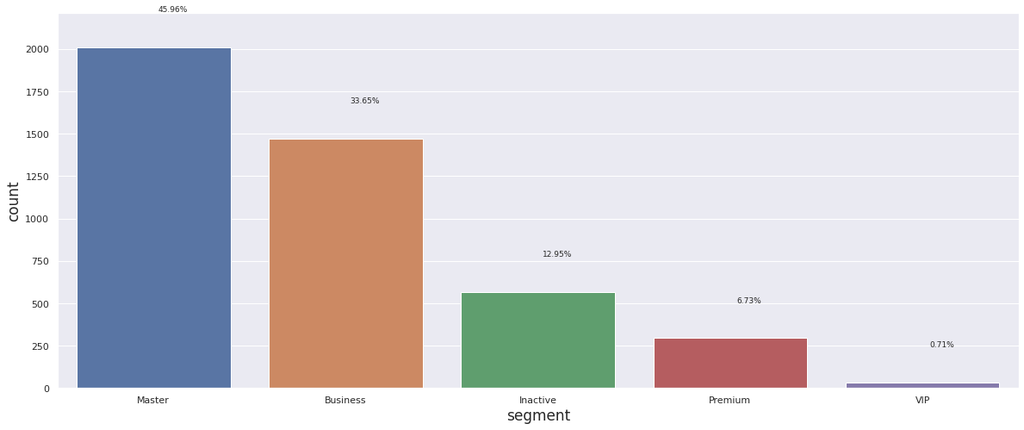

```python
plot_perc('segment', df6)
```

# Frequency vs Recency

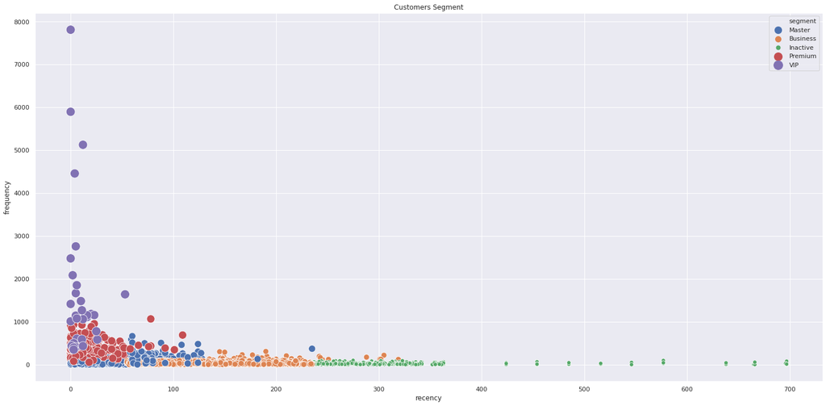

```python
plot_segment('recency','frequency', df6)
```

# Monetary vs Frequency

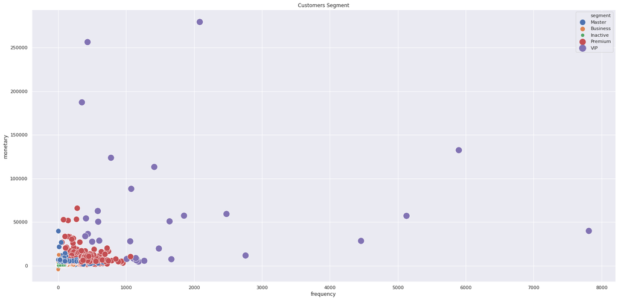

```python
plot_segment('frequency', 'monetary', df6)
```

# Monetary vs Recency

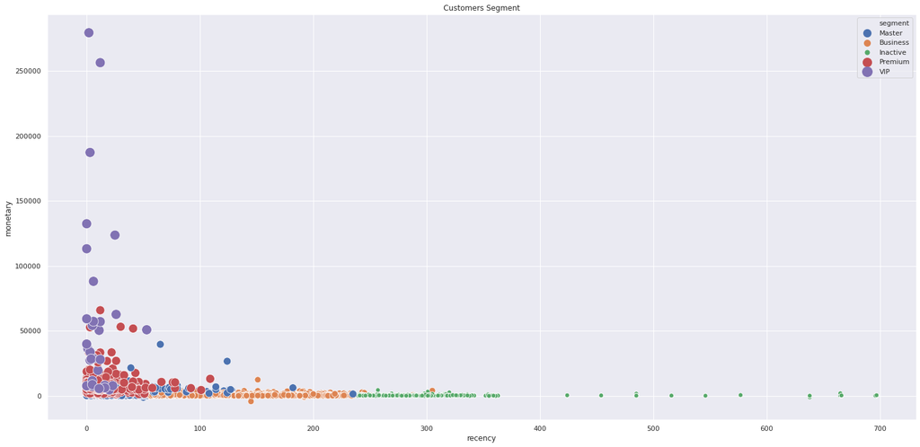

```python
plot_segment('recency', 'monetary', df6)
```

# Actions for Marketing

- Recover Inactive customers through promotions or cunpons.
- Provide special discounts to Master and Business customers.
- Personalized service to Premium customers.
- Offer innovative products to VIP customers.